# cavega_OriginalHomeworkCode_02

C. Vega

9/16/2019

# This is the code for [Homework 2](https://fuzzyatelin.github.io/bioanth-stats/homework-02.html)

# The premise for this homework is:

> Every Saturday morning, at the same time, a primatologist goes and sits in the forest to listen for titi monkey calls, counting the number of calls they hear in a 2 hour window from 5am to 7am. Based on previous knowledge, she believes that the mean number of calls she will hear in that time is exactly 15. Let X represent the appropriate Poisson random variable of the number of calls heard in each monitoring session.

## Question 1: What is the probability that she will hear more than 8 calls during any given session?

### For this I am using the ppois function, where lambda is the average, and the variable is the first number in the parentheses, i will use the call >lower.tail=FALSE to look at the probability of getting a number greater than 8

### My answer shows that there is a 96.3% chance that there will be more than 8 calls in a two-hour window.

```r
ppois(8, lambda = 15, lower.tail = FALSE)
```

```
## [1] 0.9625535
```

## Question 2: What is the probability that she will hear no calls in a session?

### Here I am using ppois again to test the probability that she will not hear any calls. I am not including >lower.tails because it is automatically set to TRUE in this function

### My answers shows that there is a 0.00003059% chance of hearing 0 calls in a two hour session.

```r
ppois(0, lambda = 15)
```

```
## [1] 3.059023e-07
```

## Question 3: What is the probability that she will hear exactly 3 calls in a session?

### The probability of hearing exactly 3 calls is 0.017%

```r
dpois(x = 3, lambda = 15)
```

```
## [1] 0.0001720701
```

## Question 4: Plot the relevant Poisson mass function over the values in range 0 ≤ x ≤ 30.

### I will be using code from Module 8 to make a plot of the probability of values from 0 to 30

### Originally tried this but it is wrong:

```
> barplot(ppois(x, lambda=l),
      ylim=0:1, space=0, names.arg = x, xlab = "Number of Calls",
      ylab= "Probability", main="Question 4: Poisson Mass Function for Titi Calls")
```

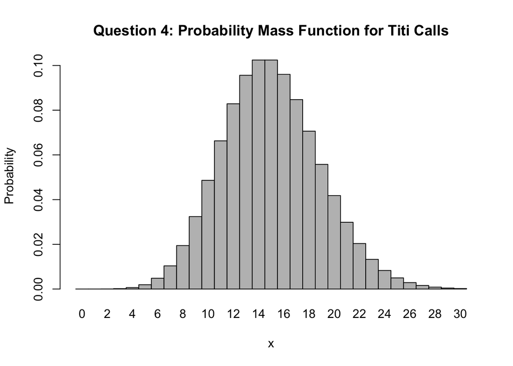

```r
x <- 0:30
l <- 15

barplot(dpois(x=x,lambda=l),  names.arg=x,space=0,xlab="x",ylab="Probability",main="Question 4: Probability Mass Function for Titi Calls")
```

## Question 5: Simulate 104 results from this distribution (i.e., 2 years of Saturday monitoring sessions).

### I am using rnorm to simulate 104 observations, with an expected mean of 15 within the interval 0:30. I took the mean of this result (v) to see if it made sense. (It changes every time because it is a new random set of numbers every time.)

```r
v <- rnorm(104, 15)
mean(v)
```

```
## [1] 15.02998
```

## Question 6: Plot the simulated results using hist() and use xlim() to set the horizontal limits to be from 0 to 30. How does your histogram compare to the shape of the probability mass function you plotted above?

### I tried plotting this with the limits from 0:30 as the question asks, but this does not seem like the proper result.

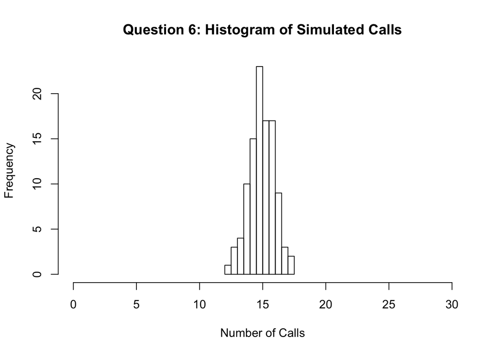

```r
v <- rnorm(104, 15,)

hist(v, xlim = c(0,30), xlab = "Number of Calls", ylab= "Frequency", main = "Question 6: Histogram of Simulated Calls")
```

# Peer Commentary (5 Challenges)

## 1. I am very unfamiliar with probability, so when I came up with an answer for the first few questions, I did not know what a “reasonable” answer would be.

## 2. It took me a lot of time to figure out which code to use to make the graphs

## 3. Even with the amount of time spent on figuring out the graphs (Questions 4 and 6), I am still not sure that they are correct.

## 4. I do not think that I correctly bootstrapped/ simulated the results for Questions 5 and 6.

## 5. It took me a long time to get through Module 8, and I still wouldn’t be able to identify when to use each type of distibution plot.